# Linear Regression Analysis - US Crime

Hannah Pavlovich

2024-02-04

The purpose of this portion is to perform Linear Regression Analysis on the Data Set and choose the best model based on $R^2_{adj}$ and Goodness-of_fit tests. In this exercise, I do not split the data because the sample set is very low at 47 entries. After standard linear regression, linear regression with predictor selection and Box-Cox Transformation are performed.

```r
### Read in the data
crimedata <- read.table("data/uscrime.txt", stringsAsFactors = FALSE, header = TRUE)
```

#### Linear Regression Analysis - All Predictors

For this basic exercise, we do not split the data into training and testing. This is partially due to the small dataset, with only 47 data points

```r
crime_lm_all <- lm(Crime ~., data = crimedata) # create a linear model
summary(crime_lm_all) # output summary
```

```
##
## Call:
## lm(formula = Crime ~ ., data = crimedata)
##
## Residuals:
##     Min      1Q  Median      3Q     Max
## -395.74  -98.09   -6.69  112.99  512.67
##
## Coefficients:
##               Estimate Std. Error t value Pr(>|t|)
## (Intercept) -5.984e+03  1.628e+03  -3.675 0.000893 ***
## M            8.783e+01  4.171e+01   2.106 0.043443 *
## So          -3.803e+00  1.488e+02  -0.026 0.979765
## Ed           1.883e+02  6.209e+01   3.033 0.004861 **
## Po1          1.928e+02  1.061e+02   1.817 0.078892 .
## Po2         -1.094e+02  1.175e+02  -0.931 0.358830
## LF          -6.638e+02  1.470e+03  -0.452 0.654654
## M.F          1.741e+01  2.035e+01   0.855 0.398995
## Pop         -7.330e-01  1.290e+00  -0.568 0.573845
## NW           4.204e+00  6.481e+00   0.649 0.521279
## U1          -5.827e+03  4.210e+03  -1.384 0.176238
## U2           1.678e+02  8.234e+01   2.038 0.050161 .
## Wealth       9.617e-02  1.037e-01   0.928 0.360754
## Ineq         7.067e+01  2.272e+01   3.111 0.003983 **
## Prob        -4.855e+03  2.272e+03  -2.137 0.040627 *
## Time        -3.479e+00  7.165e+00  -0.486 0.630708
## ---
## Signif. codes:  0 '***' 0.001 '**' 0.01 '*' 0.05 '.' 0.1 ' ' 1
##
## Residual standard error: 209.1 on 31 degrees of freedom
## Multiple R-squared:  0.8031, Adjusted R-squared:  0.7078
## F-statistic: 8.429 on 15 and 31 DF,  p-value: 3.539e-07
```

The output provides us with estimates for the coefficients for the linear model and information and guesses at their statistical signficances, the p-values. I am most interested in the low p-values as these indicate higher statistical significance

```r
which(summary(crime_lm_all)$coeff[,4]<0.05) #extracts which variables have p-values below alpha = 0.05
```

```
## (Intercept)           M          Ed        Ineq        Prob
##           1           2           4          14          15
```

The above code gives us the M, Ed, Ineq, and Prob have the highest statistical significance the relationship to the response variable, crime. This is interesting, but not particularly helpful for building our model!

### Linear Regression Analysis - Selected Predictors

Then I run another linear model to see if it provides a better fit.

```r
## create the selective linear model
crime_lm <- lm(Crime ~ M + So + Ed + Po1 + LF + M.F + Pop + NW + U2 + Wealth +
                 Ineq + Prob + Time, data = crimedata)
summary(crime_lm)
```

```
##
## Call:
## lm(formula = Crime ~ M + So + Ed + Po1 + LF + M.F + Pop + NW +
##     U2 + Wealth + Ineq + Prob + Time, data = crimedata)
##
## Residuals:
##     Min      1Q  Median      3Q     Max
## -411.47  -86.36   -2.56  102.78  523.18
##
## Coefficients:
##               Estimate Std. Error t value Pr(>|t|)
## (Intercept) -5781.4546  1515.0540  -3.816 0.000565 ***
## M              93.9001    41.8787   2.242 0.031788 *
## So             77.6600   138.6995   0.560 0.579318
## Ed            161.1992    60.1525   2.680 0.011402 *
## Po1           108.7879    22.1963   4.901 2.47e-05 ***
## LF            495.5981  1287.4423   0.385 0.702746
## M.F             4.1693    17.3324   0.241 0.811391
## Pop            -1.0745     1.2790  -0.840 0.406903
## NW              1.0884     6.1601   0.177 0.860840
## U2             86.5139    52.1369   1.659 0.106519
## Wealth          0.1028     0.1039   0.990 0.329558
## Ineq           74.4182    22.7567   3.270 0.002518 **
## Prob        -4262.3744  2206.1897  -1.932 0.061982 .
## Time           -0.2103     6.7226  -0.031 0.975236
## ---
## Signif. codes:  0 '***' 0.001 '**' 0.01 '*' 0.05 '.' 0.1 ' ' 1
##
## Residual standard error: 210.8 on 33 degrees of freedom
## Multiple R-squared:  0.7869, Adjusted R-squared:  0.703
## F-statistic: 9.376 on 13 and 33 DF,  p-value: 1.108e-07
```

### Goodness of Fit - Residual Analysis

Next, we do a goodness of fit test to see how well this model actually fits the data.

During our EDA, we did an analysis not related to residuals, like the scatterplot analysis. We checked the linearity assumption during the EDA and found that it did not hold for most predictor variables, but there was some fit.

#### Constance Variance Assumption

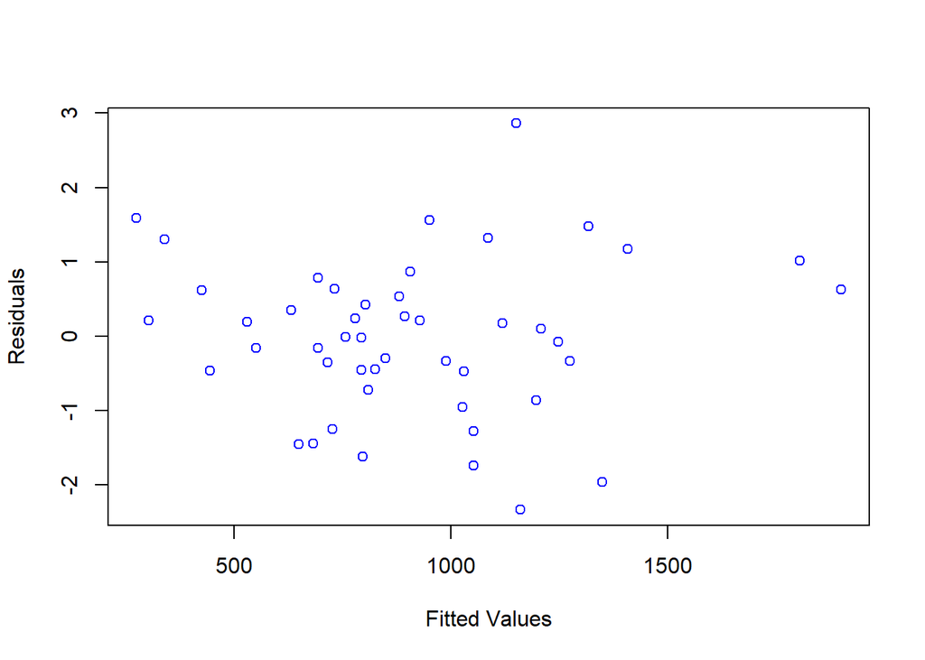

```r
resids = rstandard(crime_lm) # find standard residuals
#plot residuals against the fitted variables for constant variance
plot(x = crime_lm$fitted.values, y = resids, xlab = ('Fitted Values'),
     ylab = ("Residuals"), col = "blue")
```

We want to check if $\sigma^2$ is constant across the model. The relatoinship between fitted values and residuals is not consistent, so it does not pass the constant variance assumption. However, the constant variance could be much worse.

#### Normality Assumption

If the linear model holds, the distribution of the residuals should be normal. To check this, we do a qqnorm plot and histogram plot.

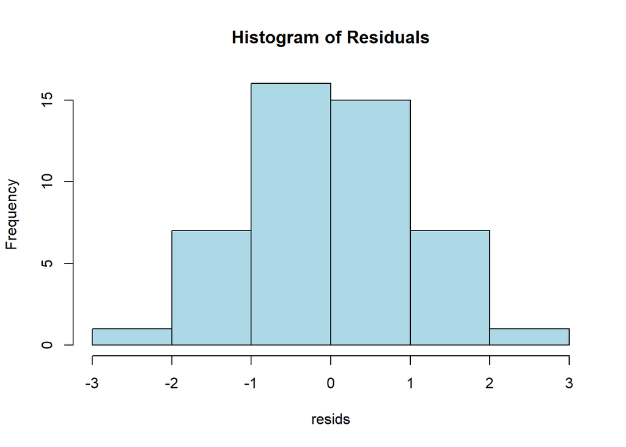

```r
hist(resids, border = "black", col = "lightblue", main = "Histogram of Residuals")
```

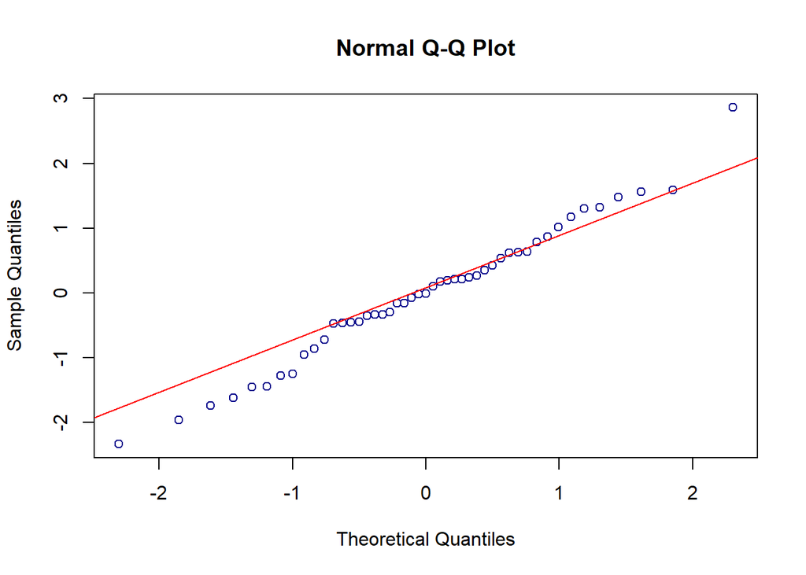

```r
#check normality assumption with qqplot
qqnorm(resids, col = "darkblue")
qqline(resids, col = "red")
```

Looking at this distribution, it looks almost normal, but the spread at the tails is not correct. The Normal QQ Plot does not stick to the line, especially at the tails. For these reasons, the normality assumption does not hold.

#### Independence Assumption

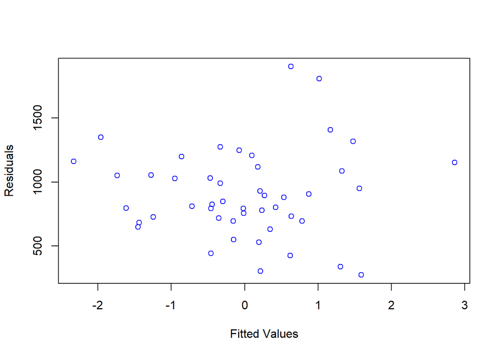

```r
plot(x = resids, y =  crime_lm$fitted.values, xlab = ('Fitted Values'),
     ylab = ("Residuals"), col = "blue")
```

Here we are checking for uncorrelated errors. There does not look like their is any clumping, which means that there are not any correlated errors, which means our errors are independent of one another.

### Transform the Data

While there are more tests we can run, transforming the data is the next step as the model is not holding well with the assumptions.

```r
bc <- boxCox(crime_lm, lambda = seq(-2, 2, 1/10))
```

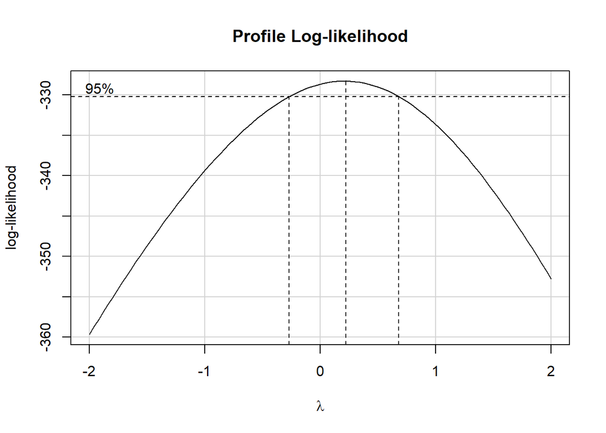

```r
lambda <- bc$x[which.max(bc$y)]
lambda_round <- round(lambda*2)/2
bc
```

[output not shown]

[output cut: 20 more lines]

```r
paste("ideal lambda = ", lambda_round)
```

```
## [1] "ideal lambda =  0"
```

According to this, the ideal $\lambda$ is 0, which suggestions we do a log transformation on the data. Should we try it?

```r
## Create new linear model using the log of crime (response variable)
crime_t = lm(log(Crime)~ M + So + Ed + Po1 + LF + M.F + Pop + NW +
    U1 + Wealth + Ineq + Prob + Time, data =crimedata)
summary(crime_t)
```

```
##
## Call:
## lm(formula = log(Crime) ~ M + So + Ed + Po1 + LF + M.F + Pop +
##     NW + U1 + Wealth + Ineq + Prob + Time, data = crimedata)
##
## Residuals:
##      Min       1Q   Median       3Q      Max
## -0.42494 -0.07987  0.02010  0.11837  0.45741
##
## Coefficients:
##               Estimate Std. Error t value Pr(>|t|)
## (Intercept)  0.8148166  1.7388786   0.469 0.642445
## M            0.1027990  0.0466452   2.204 0.034621 *
## So           0.1709764  0.1644806   1.039 0.306132
## Ed           0.1633585  0.0657627   2.484 0.018240 *
## Po1          0.1057113  0.0261520   4.042 0.000298 ***
## LF           0.7377832  1.6015518   0.461 0.648059
## M.F         -0.0129498  0.0227607  -0.569 0.573241
## Pop         -0.0011171  0.0014640  -0.763 0.450849
## NW           0.0026600  0.0070464   0.377 0.708224
## U1           2.9607701  2.9911269   0.990 0.329450
## Wealth       0.0002027  0.0001162   1.744 0.090385 .
## Ineq         0.0874951  0.0255902   3.419 0.001689 **
## Prob        -5.5570348  2.4884280  -2.233 0.032437 *
## Time        -0.0040402  0.0075709  -0.534 0.597163
## ---
## Signif. codes:  0 '***' 0.001 '**' 0.01 '*' 0.05 '.' 0.1 ' ' 1
##
## Residual standard error: 0.2377 on 33 degrees of freedom
## Multiple R-squared:  0.7601, Adjusted R-squared:  0.6655
## F-statistic: 8.041 on 13 and 33 DF,  p-value: 6.602e-07
```

The summary here gives us a higher P-value and lower adjusted R-squared, which means that the model is less correct than before the transform. However, we can transform ALL data, not just the response. Let’s stop and go back to before!

### Conclusion: Predicting the Model

```r
summary(crime_lm)
```

```
##
## Call:
## lm(formula = Crime ~ M + So + Ed + Po1 + LF + M.F + Pop + NW +
##     U2 + Wealth + Ineq + Prob + Time, data = crimedata)
##
## Residuals:
##     Min      1Q  Median      3Q     Max
## -411.47  -86.36   -2.56  102.78  523.18
##
## Coefficients:
##               Estimate Std. Error t value Pr(>|t|)
## (Intercept) -5781.4546  1515.0540  -3.816 0.000565 ***
## M              93.9001    41.8787   2.242 0.031788 *
## So             77.6600   138.6995   0.560 0.579318
## Ed            161.1992    60.1525   2.680 0.011402 *
## Po1           108.7879    22.1963   4.901 2.47e-05 ***
## LF            495.5981  1287.4423   0.385 0.702746
## M.F             4.1693    17.3324   0.241 0.811391
## Pop            -1.0745     1.2790  -0.840 0.406903
## NW              1.0884     6.1601   0.177 0.860840
## U2             86.5139    52.1369   1.659 0.106519
## Wealth          0.1028     0.1039   0.990 0.329558
## Ineq           74.4182    22.7567   3.270 0.002518 **
## Prob        -4262.3744  2206.1897  -1.932 0.061982 .
## Time           -0.2103     6.7226  -0.031 0.975236
## ---
## Signif. codes:  0 '***' 0.001 '**' 0.01 '*' 0.05 '.' 0.1 ' ' 1
##
## Residual standard error: 210.8 on 33 degrees of freedom
## Multiple R-squared:  0.7869, Adjusted R-squared:  0.703
## F-statistic: 9.376 on 13 and 33 DF,  p-value: 1.108e-07
```

Now let’s get to our prediction!

```r
## create a prediction based on the crime_lm linear model, which is an
## untransformed model with two predictor variables removed

test_point = data.frame(M = 14.0, So = 0, Ed = 10.0, Po1 = 12.0, Po2 = 15.5,
                        LF = 0.640, M.F = 94.0, Pop = 150, NW = 1.1, U1 = 0.120,
                        U2 = 3.6, Wealth = 3200, Ineq = 20.1, Prob = 0.04, Time = 39.0)

cat("Prediction for Test Point =", predict(crime_lm, test_point))
```

```
## Prediction for Test Point = 957.369
```

**My prediction for the test data set is 957.369.**

I created three linear models to test the crime data, one with all of the data, one with a lower amount of data, and one with the response variable transformed by the natural log. I then looked at the $R^2$ values and the p-values. A higher $R^2$ and lower p-value indicates better goodness of fit for our model.

I chose to disregard the first model with all variables because there was collinearity among two sets of predictor variables. While it had the highest $R^2$, I did not trust it.